# A3: SPL Library Checkouts

### Introduction

The data analyzed here provides great insight into checkouts from the Seattle Public Library from 2017 to January of 2023. As a kid I checked out many stories from my hometown library. I particularly loved listening to audiobooks on long car rides and on days with little to do to fill my time. I did not have access to ebooks or digital audiobooks from the library until I was older, and the audiobooks I listened to were on DVD and sometimes still referred to as ‘books on tape’. Now, with access to the expansive SPL data, I seek to find out how library checkouts of newer, digital audiobooks and digitally-formatted books in general have evolved since I was a kid. I also want to examine the connection between checkouts and time of year, since I always wanted to know if people really do read more in the Summer, as library posters I saw growing up always encouraged.

### The Dataset

The Seattle Public Library collected and published this data. It includes each title that was checked out at least 10 times in a month. Recorded is the month and year of checkout, number of checkouts in that month, title, subject material, author, publisher, year of publication, ISBN number, format, and checkout method. This subset of the data was collected from a combination of various digital library systems (Overdrive, hoopla, Freegal, and RBDigital) and the Horizon IPL. This data was collected as a part of a greater initiative by the city of Seattle to provide community data to citizens and to promote new financial and research opportunities. One ethical dilemma presented by this data is the subject of library patrons’ checkout privacy. What could the consequences of collecting data on the consumption of free information be? Could this data be used to defend the censorship of free knowledge? One issue with this data is that it is collected monthly over a period of decades and this makes it more difficult to graph trends over time in R. Another issue is a lack of continuity in how the same piece of media’s title is formatted throughout the data set. Another limitation I noticed in particular during my work with this data is the fact that it only digital audiobooks are labeled as audiobooks, and that audiobooks on disc or cassette are very difficult to distinguish from the many other forms of media on disc or cassette.

### First Trends Over Time Chart

I wanted to analyze how the popularity of physical books vs. digitally-formatted books has changed over time. A normal pattern of slightly decreasing physical checkouts and increasing digital ones began to emerge. However, the pandemic disrupts these patterns, greatly decreasing the number of physical checkouts and possibly contributing to the growth of digital ones.

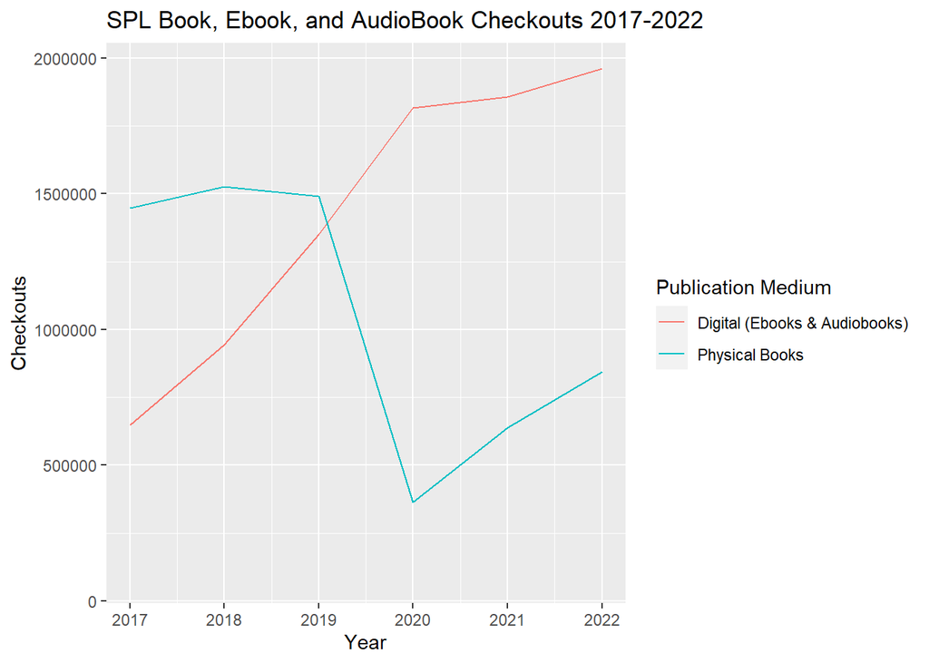

### Second Trends Over Time Chart

Here I sought to analyze the popularity of written books compared to audiobooks over time. While the total checkouts for audiobooks remains considerably lower than that of books and ebooks, this may be slightly impacted by the exclusion of disc and cassette audiobooks. The dip in book checkouts due to the pandemic is also clearly visible in this chart. excludeing this phenomena, both audiobook and written book checkouts seem to be increasing at a similar rate.

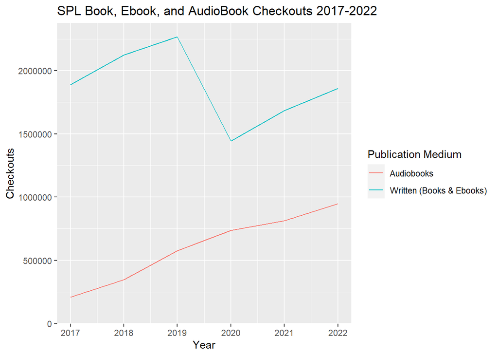

### Your Choice

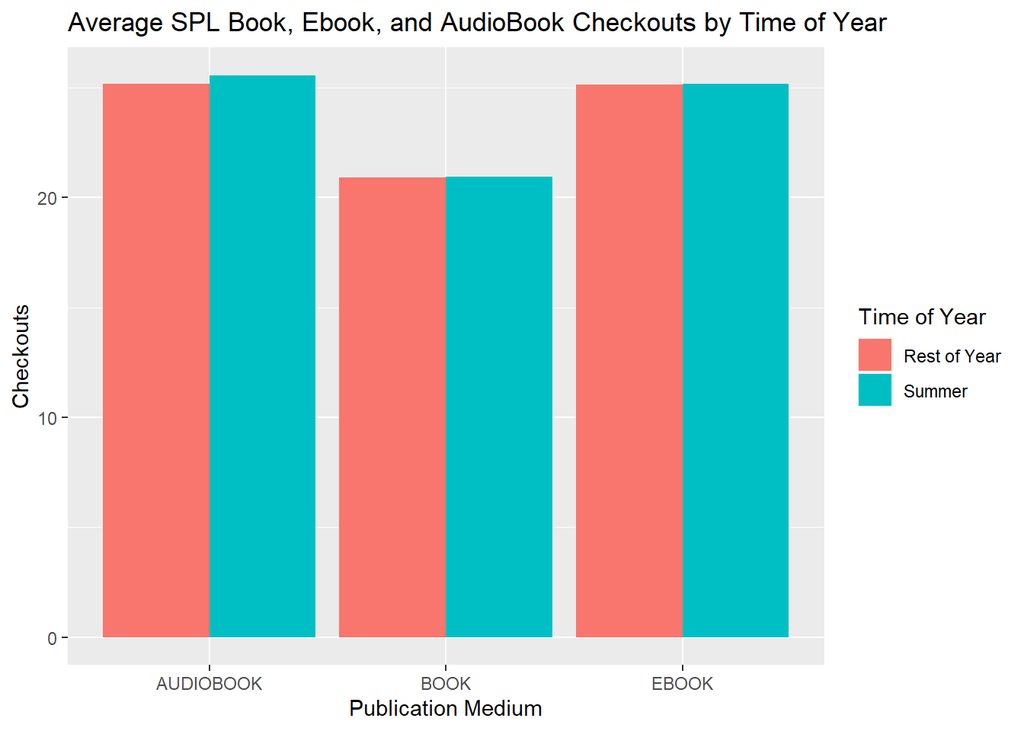